# Height Meta-analysis for African ancestry

[output not shown]

```r
set.seed(4194)
cols2<-unname(sample(unlist(wesanderson::wes_palettes),15))
res1<-readRDS('resPRS1_ML.RDs')
nams<-rownames(res1[[1]])
nams2<-names(res1)
res1<-lapply(1:5, function(x) as.data.table(as.data.frame(res1[[x]])))
res1<-lapply(res1, function(x) x[,Set:=nams])
res1<-lapply(1:5, function(x) res1[[x]][,Test_Data:=nams2[x]])
res2<-do.call(rbind, res1)
res3<-as.data.table(melt(res2, id.vars=c('Set', 'Test_Data')))
res3[,Alpha:=as.numeric(gsub("alpha","",variable))]
res3[,value:=round(value,1)]
res3[,Set:=gsub("PRS_", "", Set)]
do.call(rbind, (res3 %>% group_by(Test_Data) %>% mutate(Test=Test_Data) %>% arrange(-value) %>% group_map(~head(.x, 5L))))
```

| Set | variable | value | Alpha | Test |
| --- | --- | --- | --- | --- |
| PAGE--META_EUR | alpha0.7 | 7.7 | 0.7 | HRS_AFR |
| META_EUR--META_NEA | alpha0.3 | 7.6 | 0.3 | HRS_AFR |
| META_EUR--META_NEA | alpha0.4 | 7.6 | 0.4 | HRS_AFR |
| PAGE--META_EUR | alpha0.6 | 7.5 | 0.6 | HRS_AFR |
| PAGE--META_EUR | alpha0.8 | 7.5 | 0.8 | HRS_AFR |
| UKBB--GIANT | alpha0.2 | 25.9 | 0.2 | HRS_EUR |
| UKBB--GIANT | alpha0.3 | 25.7 | 0.3 | HRS_EUR |
| UKBB--META_EUR | alpha0.3 | 25.7 | 0.3 | HRS_EUR |
| UKBB--META_EUR | alpha0.4 | 25.7 | 0.4 | HRS_EUR |
| UKBB--META_EUR | alpha0.5 | 25.6 | 0.5 | HRS_EUR |

[output cut: 15 more lines]

```r
pA<-res3[Test_Data %in% c('PMBB_AFR', 'HRS_AFR', 'UKB_CHI')] %>%
        filter(Set %in% unique(do.call(rbind, (res3 %>% filter(Test_Data %in% c('PMBB_AFR', 'HRS_AFR', 'UKB_CHI')) %>% group_by(Test_Data) %>% mutate(Test=Test_Data) %>% arrange(-value) %>% group_map(~head(.x, 5L))))$Set)) %>% mutate(Set=fct_reorder(Set, value)) %>% ggplot(aes(x=Alpha, y=value, color=Set)) + facet_wrap(~Test_Data)+geom_line() +
        scale_color_manual(name='Summary Statistics',values = cols2[1:12])  + scale_y_continuous(breaks = seq(0, 20, by = 2)) + theme_bw()
#
res1<-readRDS('resPRS2_BM.RDs')
nams<-rownames(res1[[1]])
nams2<-names(res1)
res1<-lapply(1:3, function(x) as.data.table(as.data.frame(res1[[x]])))
res1<-lapply(res1, function(x) x[,Set:=nams])
res1<-lapply(1:3, function(x) res1[[x]][,Test_Data:=nams2[x]])
res2<-do.call(rbind, res1)
res4<-as.data.table(melt(res2, id.vars=c('Set', 'Test_Data')))
res4[,Alpha:=as.numeric(gsub("alpha","",variable))]
res4[,value:=round(value,1)]
res4[,Set:=gsub("PRS_", "", Set)]
res4 %>% group_by(Test_Data) %>% mutate(Test=Test_Data) %>% arrange(-value) %>% group_map(~head(.x, 2L))
```

| Set | variable | value | Alpha | Test |
| --- | --- | --- | --- | --- |
| META_EUR--META_NEA | alpha0.1 | 6.6 | 0.1 | HRS_AFR |
| META_EUR--META_NEA | alpha0 | 6.4 | 0.0 | HRS_AFR |

| Set | variable | value | Alpha | Test |
| --- | --- | --- | --- | --- |
| META_ALL--META_NEA | alpha0.2 | 7.1 | 0.2 | PMBB_AFR |
| META_ALL--META_NEA | alpha0.1 | 7.0 | 0.1 | PMBB_AFR |

| Set | variable | value | Alpha | Test |
| --- | --- | --- | --- | --- |
| UKBB--BBJ | alpha0.2 | 13.9 | 0.2 | UKB_CHI |
| UKBB--BBJ | alpha0.3 | 13.6 | 0.3 | UKB_CHI |

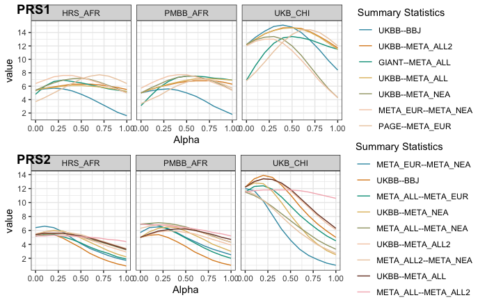

```r
pB<-res4 %>%
        filter(Set %in% unique(do.call(rbind, (res4 %>% group_by(Test_Data) %>% mutate(Test=Test_Data) %>% arrange(-value) %>% group_map(~head(.x, 5L))))$Set)) %>% mutate(Set=fct_reorder(Set, value)) %>% ggplot(aes(x=Alpha, y=value, color=Set)) + facet_wrap(~Test_Data)+geom_line() +
        scale_color_manual(name='Summary Statistics',values = cols2[1:12])  + scale_y_continuous(breaks = seq(0, 20, by = 2)) + theme_bw()
#
cowplot::plot_grid(pA,pB, labels=c("PRS1", "PRS2"), nrow=2)
```

# Background

In our previous work, we analysed the factors that drive reduced prediction accuracy of polygenic scores for height in individuals with African ancestry.

We saw that SFS and LD play a role, but there is also suggestive evidence that differences in marginal effect sizes exist.

In that study we ran a GWAS in ~8,000 individuals with African ancestry from the UKBB and tested for differences in marginal effect sizes between those and European derived effect sizes, as well as correlations of those differences with allelic frequency differences. Finally, we implemented ancestry-informed PRSs in the admixed individuals, and observed only very modest improvement in prediction accuracy.

Another interesting thing is to see whether by fine-mapping index variants by including African ancestry we can select SNPs that yield better PRS performance.

Questions:

1. Do multi-PRS and LA-PRS increase in prediction by using effect-sizes from a meta-African analysis? What about a meta-Pan analysis?
2. What is the overlap between GWAS hits between GWAS for EUR only and BBJ only, AFR only and combinations of those?
3. When we select ancestry-specific index variants and then use those in the PRS, does prediction improve?

# Methods

For now, we are focusing on height only.

## GWAS summary statistics

We use GWAS summary statistics for height from six sources::

*UKBB_eur: UK Biobank Europeans

*BBJ: Biobank Japan

*Uganda Genome Project - which is a meta-analysis of Uganda + 3 other populations from Africa, described in the Uganda Genome Project paper);

- UKBB_afr- from the African subset from the panUKBB dataset.
- N’diaye et al. 2011 - still the largest height GWAS performed in African ancestry individuals;
- PAGE, a large meta-analysis including 35% African Americans and the remaining participants are mostly of Hispanic/Latino and other minority ancestries.

So our meta-AFR analysis includes: PAGE, Ndiaye, UKBB_afr and 4 cohorts from UGP.

Our meta-all analysis includes: meta-AFR, UKBB_eur, BBJ.

## Meta-analysis in METAL

We performed two meta-analysis:

We ran a meta-analysis using METAL using one file for each of the above datasets. We set genomic correction to “ON”, meaning it is performed for each file (not the final values). We performed the meta-analysis using SCHEME STDERR, meaning betas and SE are used. For the meta-AFR analysis, we set AVERAGEFREQ and MINMAXFREQ to “ON” so that metal can track large allelic frequency differences across datasets as suggestion of allelic mismatch. We only report results for variants that have a combined weight of at least 49,781 (meta-AFR) or 590026 individuals, resulting in about 20 million autosomal variants in both datasets.

We inspected the p-value distribution of these meta-analyses using QQ-plots and calculated the genomic inflation on the final p-values, and performed corrections accordingly.

## Summary statistics QC

Most were in hg19 build, except N’diaye, which we lift over from hg18 to hg19. Previous filtering was done in each of these studies, and there is often not enough information for us to perform our own filtering.

PAGE: inverse-normal-adjusted residuals for each trait outcome. Info score available. Filtered for > 0.4 by authors prior. We were more strict and filtered for > 0.8.

As mentioned, for the meta-analyses summary statistics we only retained positions for which there was information for most individuals in the meta-analysis (20.7 and 23.7 M SNPs for meta-AFR and meta-ALL respectively).

For UKBB_eur, we retained only SNPs with INFO> 0.8 (11.9 M SNPs) and low_quality_variant=FALSE (15.4 M SNPs). Only autosomal SNPs were analyzed.

### LD reference panels

For PRS using summary statistics from the UKBB_eur, we used the UKBB_eur (5,000 randomly sampled) imputed data as LD reference panel.For PRS using the BBJ summary statictics, we used a combination of the 1000G Phase 3 East Asians and UKBB Chinese individuals. For the meta-AFR summary statistics, we used a combination of UKBB_afr and 1000G Phase 3 African ancestry individuals. For the meta-ALL summary statistics, we used a combination of all Phase 3 1000G individuals, the UKBB_eur, UKBB_afr, and UKBB_chi. In all cases, the combined sets were QC’d to only include unrelated individuals (plink –rel-cutoff 0.125) and with genotype missingness < 0.85. We further restricted these sets to SNPs with MAF > 0.001. We further removed SNPs with allelic mismatch with the UKBB_EUR summary statistics file and corrected for strand flipping when appropriate.

## Test cohorts

Genotype data from test cohorts was lifted over to hg38 when needed.

- PMBB (Penn Biobank): with sets of EUR (7501) and AFR ancestry individuals (9226)
- UKB_CHI (UKBB Chinese): a set of 1,504 individuals with Chinese ancestry from the UK Biobank.
- HRS (Health and Retirement Study): with sets of EUR (10,486) and AFR (2,322) ancestry individuals.

$$height\sim Sex+Age+Age^2+Sex*Age+Sex*Age^2+pEUR+Sex*pEUR+Age*pEUR+Age^2*pEUR$$

, where $p_{EUR}$ is the genome-wide average proportion of European ancestry for PMBB_afr and HRS_afr (estimated through RFMIx), and the European ancestry component (estimated through unsupervised ADMIXTURE with k=2) for UKB_CHI. For HRS_eur and PMBB_eur, we set $p_{EUR}$ to 1.

When multiple time points were available for each individual, we retained the one corresponding to the latest height measure and age. All height phenotype data was formatted to be in centimeters.

### PRS calculations

PRS_eur: PRS using effect sizes ($\beta$) from UKBB_eur.

PRS_eas: PRS using effect sizes ($\beta$) from BBJ (all East Asian).

PRS_afr: PRS using effect sizes (($\beta$) from the meta-AFR GWAS.

PRS_all: PRS using effect sizes (($\beta$) from the meta-ALL GWAS.

1. A simple linear regression model

$$height~Sex+Age+Age2+pEUR$$

$$height~Sex+Age+Age2+pEUR+PRS_{eur}$$

2. PRS1_ML (described in Marquez-Luna et al. 2017 and Bitarello & Mathieson 2020)
3. PRS2_BD - linear combination of PRS described in Bitarello & Mathieson 2020